# Series de tiempo: Tarea 3

Guillermo Alberto Garcia Candanosa - A01034958

2022-06-13

Carga la librería fpp2 y utiliza los datos de la base advert. Esta base de datos incluye las ventas mensuales y los anuncios publicitarios de una empresa de autopartes.

Carga de librerías:

```r
library(fpp2)
library(forecast)
library(ggplot2)
```

Carga de base de datos:

```r
advert <- advert
```

1. Haz una gráfica con autoplot.

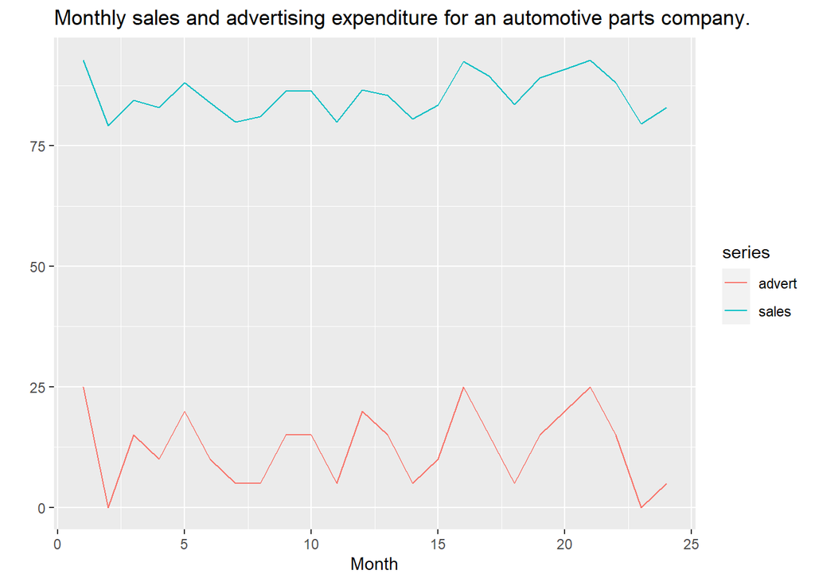

```r
# Grafico con función autoplot()

autoplot(advert) +
  ggtitle("Monthly sales and advertising expenditure for an automotive parts company.") +
  xlab("Month") +
  ylab("")
```

2. Haz una gráfica con autoplot y la función facets =TRUE. ¿Para qué nos sirve?

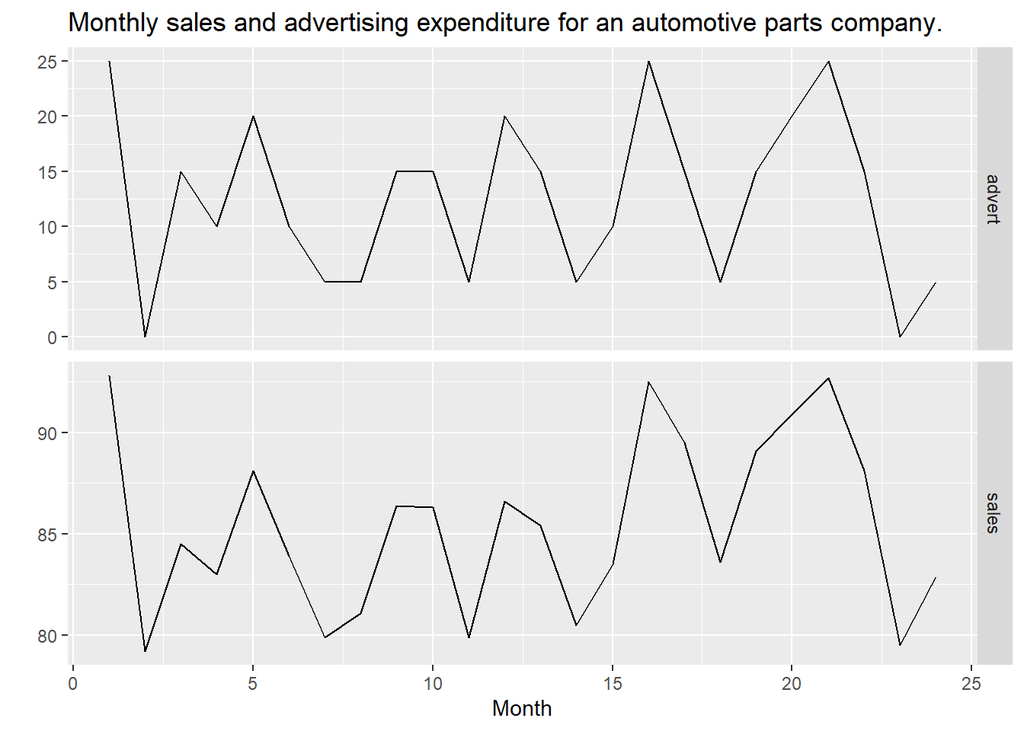

```r
# Grafico con función autoplot()

autoplot(advert, facets = TRUE) +
  ggtitle("Monthly sales and advertising expenditure for an automotive parts company.") +
  xlab("Month") +
  ylab("")
```

*R: El comando facets = TRUE nos sirve para separar las gráficas de cada serie de tiempo, de forma que se pueda apreciar el comportamiento de cada una en su escala óptima correspondiente. De esta forma se puede apreciar con mayor claridad la correlación entre las variables.*

3. Haz un modelo de regresión donde y= sales y x es advertising.

```r
# Realizamos modelo de regresión lineal múltiple en datos ts y lo almacenamos en fit.advert
fit.advert <-
  tslm(sales ~
         advert,
       data = advert)

# Desplegamos resultados del modelo
summary(fit.advert)
```

```
##
## Call:
## tslm(formula = sales ~ advert, data = advert)
##
## Residuals:
##     Min      1Q  Median      3Q     Max
## -2.8194 -1.1375 -0.2412  0.9123  2.7519
##
## Coefficients:
##             Estimate Std. Error t value Pr(>|t|)
## (Intercept) 78.73426    0.59735  131.81  < 2e-16 ***
## advert       0.53426    0.04098   13.04 7.96e-12 ***
## ---
## Signif. codes:  0 '***' 0.001 '**' 0.01 '*' 0.05 '.' 0.1 ' ' 1
##
## Residual standard error: 1.506 on 22 degrees of freedom
## Multiple R-squared:  0.8854, Adjusted R-squared:  0.8802
## F-statistic:   170 on 1 and 22 DF,  p-value: 7.955e-12
```

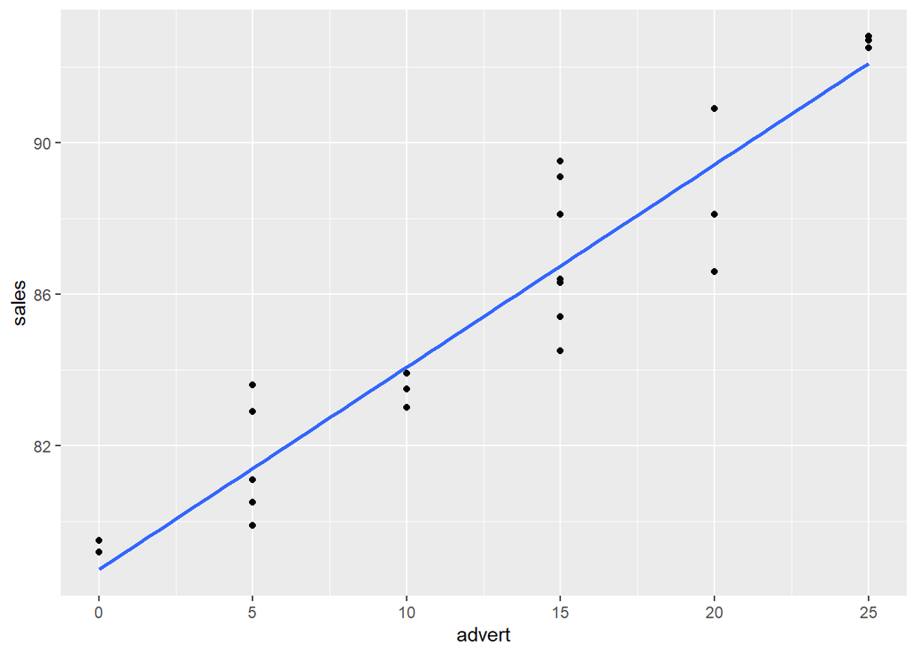

```r
# Graficamos scatter plot de sales vs advert, y sobreponemos la línea generada a partir de la regresión lineal
advert %>%
  as.data.frame() %>%
  ggplot(aes(x = advert, y = sales)) +
  geom_point() +
  geom_smooth(method = "lm",
              se = FALSE)
```

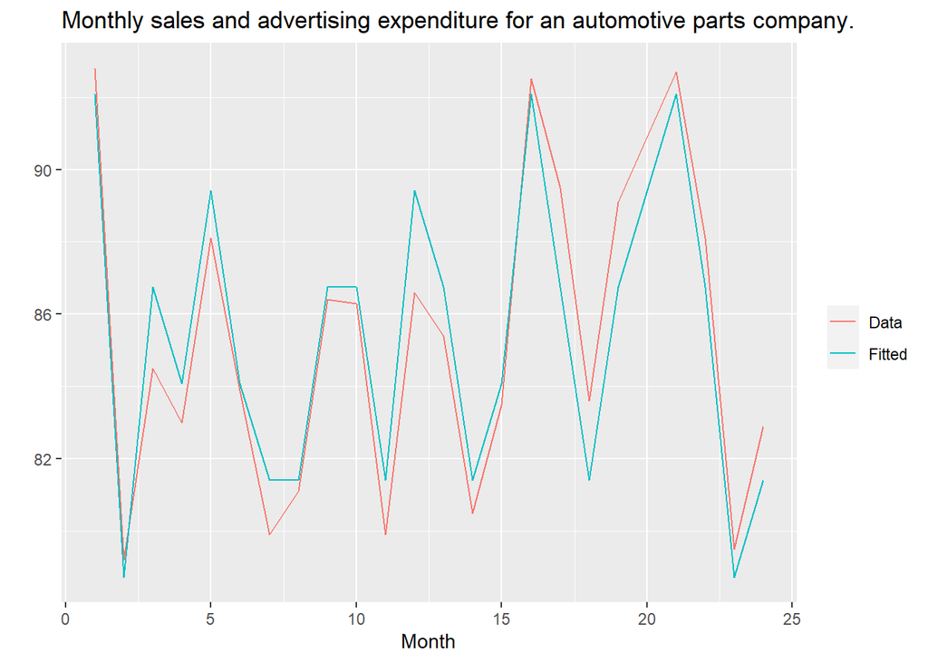

```r
# Graficamos los datos ajustados junto con la serie de tiempo original
autoplot(advert[,"sales"], series = "Data") +
  autolayer(fitted(fit.advert), series = "Fitted") +
  xlab("Month") +
  ylab("") +
  ggtitle("Monthly sales and advertising expenditure for an automotive parts company.") +
  guides(colour = guide_legend(title = ""))
```

4. ¿Los residuales tienen una autocorrelación estadísticamente significativa?

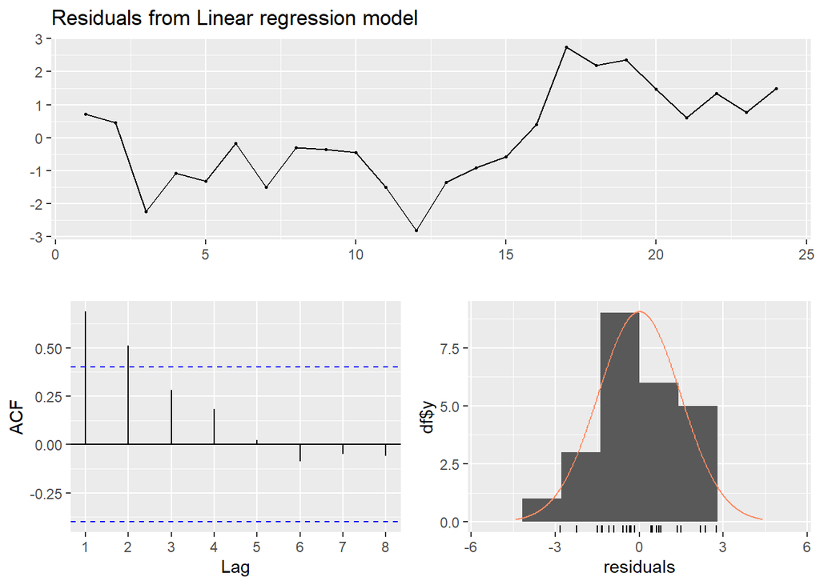

```
##
##  Breusch-Godfrey test for serial correlation of order up to 5
##
## data:  Residuals from Linear regression model
## LM test = 12.498, df = 5, p-value = 0.02856
```

```r
# Gráfica de los residuales
fit.advert %>% checkresiduals()
```

*R: Según lo identificado en el correlograma generado, que se refuerza con el bajo p-value que se genera a partir del Breusch-Godfrey test que se realizó; se puede afirmar que se rechaza la hipótesis nula y que efectivamente hay una autocorrelación estadísticamente significativa entre los residuales del modelo de regresión.*

5. Ahora haz el siguiente modelo dinámico: advert_dreg.0.0.0 <- Arima( advert[, “sales”], xreg = advert[, “advert”], order = c(0, 0, 0))

```r
# Realizamos el modelo dinámico
advert_dreg.0.0.0 <-
  Arima(advert[, "sales"],
        xreg = advert[, "advert"],
        order = c(0, 0, 0))

# Desplegamos los coeficientes del modelo
advert_dreg.0.0.0
```

```
## Series: advert[, "sales"]
## Regression with ARIMA(0,0,0) errors
##
## Coefficients:
##       intercept    xreg
##         78.7343  0.5343
## s.e.     0.5719  0.0392
##
## sigma^2 = 2.267:  log likelihood = -42.83
## AIC=91.66   AICc=92.86   BIC=95.2
```

6. ¿Los residuales del modelo advert_dreg.0.0.0 están autocorrelacionados?

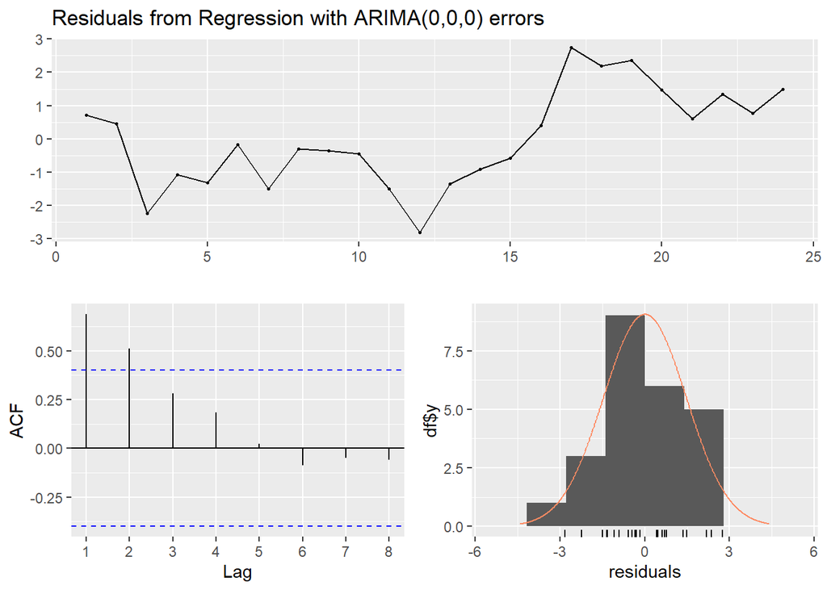

```
##
##  Ljung-Box test
##
## data:  Residuals from Regression with ARIMA(0,0,0) errors
## Q* = 23.683, df = 3, p-value = 2.91e-05
##
## Model df: 2.   Total lags used: 5
```

```r
# Revisamos los residuales generados por el modelo
advert_dreg.0.0.0 %>% checkresiduals()
```

*R: Según lo identificado en el correlograma generado, que se refuerza con el bajo p-value que se genera a partir del Ljung-Box test que se realizó; se puede afirmar que se rechaza la hipótesis nula y que efectivamente hay una autocorrelación estadísticamente significativa entre los residuales del modelo dinámico.*

7. Ahora vuelve a hacer el modelo dinámico, pero con auto.arima. ¿Qué pasó con los residuales?

```r
# Realizamos el modelo dinámico de forma automática
advert_dreg.auto <-
  auto.arima(advert[, "sales"],
             xreg = advert[, "advert"])

# Desplegamos los coeficientes del modelo
advert_dreg.auto
```

```
## Series: advert[, "sales"]
## Regression with ARIMA(0,1,0) errors
##
## Coefficients:
##         xreg
##       0.5063
## s.e.  0.0210
##
## sigma^2 = 1.201:  log likelihood = -34.22
## AIC=72.45   AICc=73.05   BIC=74.72
```

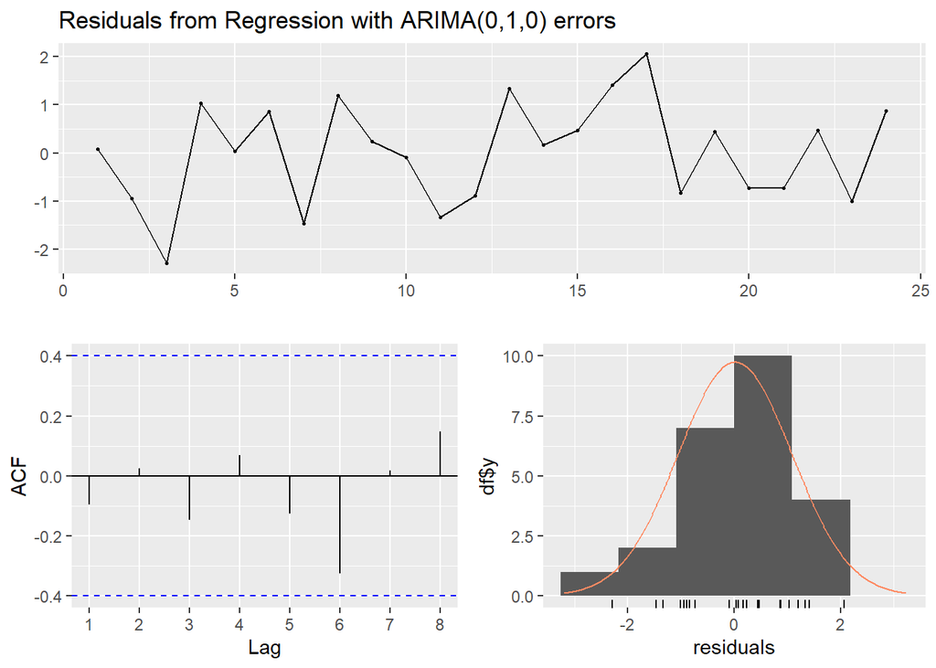

```
##
##  Ljung-Box test
##
## data:  Residuals from Regression with ARIMA(0,1,0) errors
## Q* = 1.5622, df = 4, p-value = 0.8156
##
## Model df: 1.   Total lags used: 5
```

```r
# Revisamos los residuales generados por el modelo
checkresiduals(advert_dreg.auto)
```

*R: Según lo identificado en el correlograma generado, que se refuerza con el alto p-value que se genera a partir del Ljung-Box test que se realizó; se puede afirmar que se acepta la hipótesis nula y que efectivamente no hay una autocorrelación estadísticamente significativa entre los residuales del modelo dinámico.*

8. ¿Cuál modelo es mejor? Usa los criterios de AIC y de accuracy.

```r
# Comparamos los AICc de cada modelo
advert_dreg.0.0.0$aicc
```

```
## [1] 92.86268
```

```r
advert_dreg.auto$aicc
```

```
## [1] 73.04678
```

```r
# Comparamos el error MASE derivado de cada modelo
accuracy(advert_dreg.0.0.0)[,"MASE"]
```

```
## [1] 0.2634605
```

```r
accuracy(advert_dreg.auto)[,"MASE"]
```

```
## [1] 0.189587
```

*R: Tanto el AICc como la medida del error MASE, siendo ambas menores en el modelo dinámico automático; nos indican que este modelo es mejor.*

1. Considera que el presupuesto para la publicidad es igual a $10 para cada uno de los siguientes seis meses. Genera un pronóstico y grafícalo para los próximos seis meses. Incluye los intervalos de pronóstico.

```r
# Generamos el pronóstico para 6 periodos, considerando que el gasto en publicidad será de 10 para todos estos.
advert_fcast <-
  forecast(advert_dreg.auto,
           xreg = rep(10,6))

# Desplegamos los pronósticos puntuales junto con los intervalos de pronóstico.
advert_fcast
```

```
##    Point Forecast    Lo 80    Hi 80    Lo 95    Hi 95
## 25       85.43173 84.02755 86.83591 83.28422 87.57924
## 26       85.43173 83.44592 87.41754 82.39469 88.46877
## 27       85.43173 82.99962 87.86384 81.71214 89.15133
## 28       85.43173 82.62337 88.24009 81.13671 89.72675
## 29       85.43173 82.29189 88.57157 80.62975 90.23371
## 30       85.43173 81.99220 88.87126 80.17143 90.69203
```

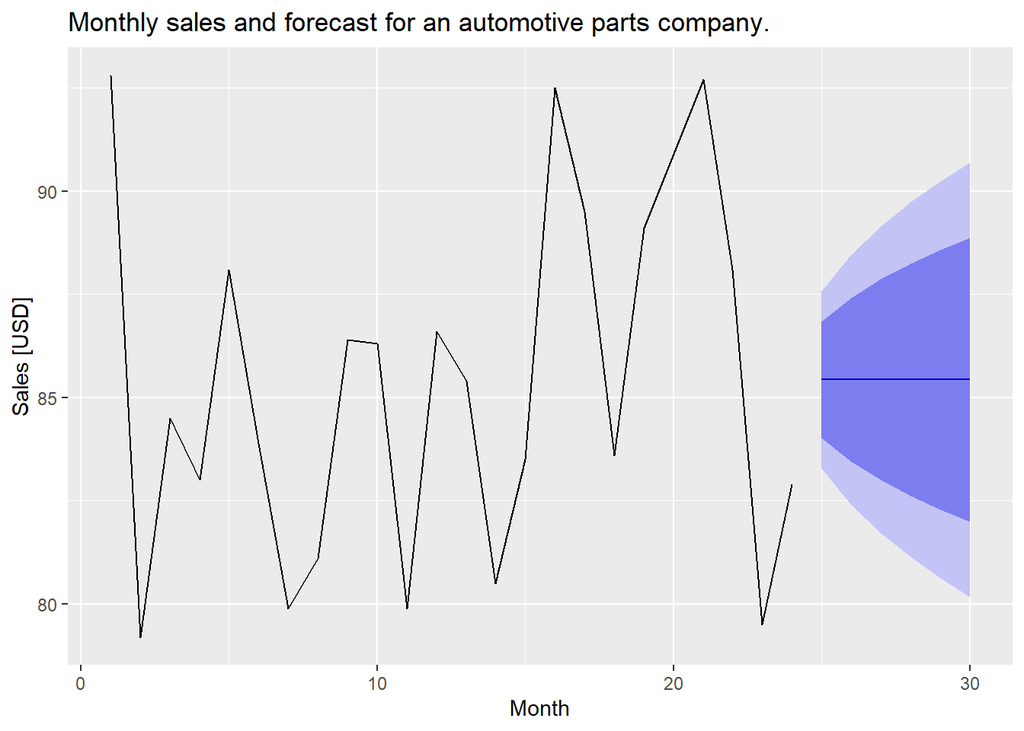

```r
# Graficamos los pronósticos puntuales y los intervalos de pronóstico.
autoplot(advert_fcast) +
  ggtitle("Monthly sales and forecast for an automotive parts company.") +
  xlab("Month") +
  ylab("Sales [USD]")
```